# Part II, INTRODUCTION TO MACHINE LEARNING

## 1.6 Classification by trees

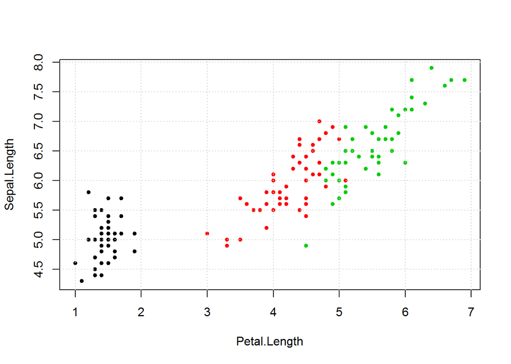

```r
data(iris)
#iris data

plot(Sepal.Length ~ Petal.Length, data=iris, pch = 20, col = as.numeric(iris$Species))
grid()
```

```r
#get the unique categorical values
(yk=unique(iris$Species))[1]
```

```
## [1] setosa
## Levels: setosa versicolor virginica
```

```r
yk=levels(iris$Species)
paste0("Species=",yk)
```

```
## [1] "Species=setosa"     "Species=versicolor" "Species=virginica"
```

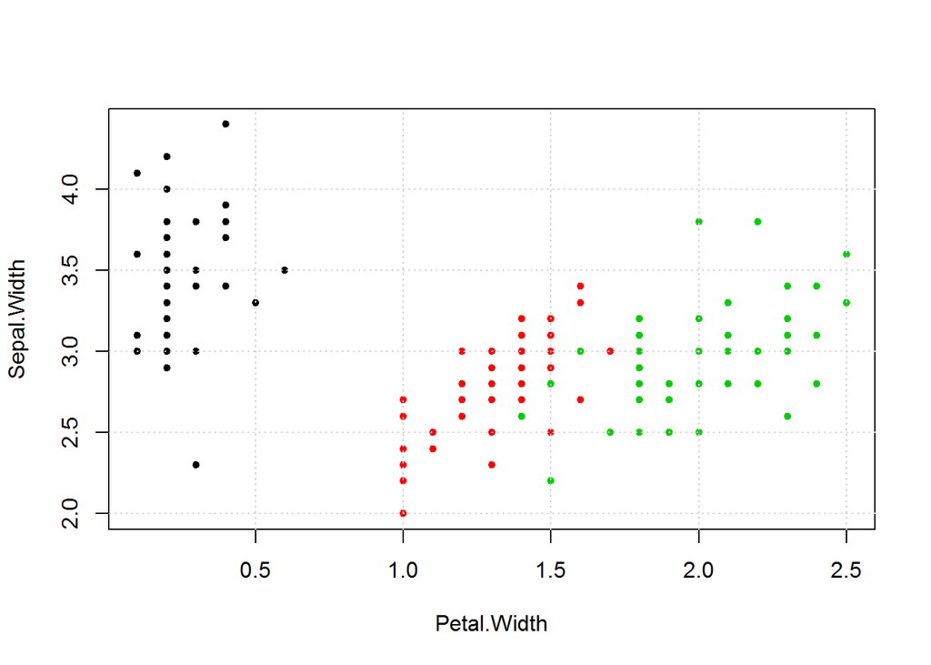

```r
plot(Sepal.Width ~ Petal.Width, data=iris, pch = 20, col = as.numeric(iris$Species))
grid()
```

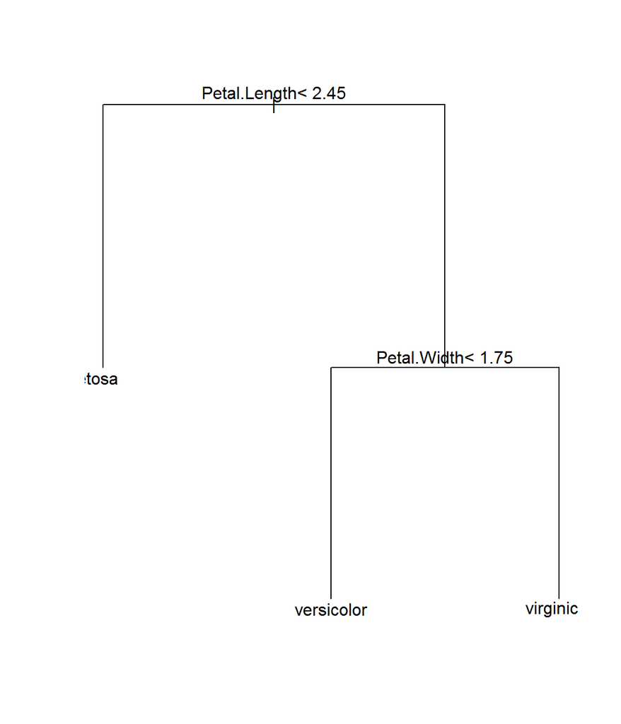

```r
library(rpart)
#par(mar=c(6,6,6,6))
myFirstTree = rpart(Species ~ ., data = iris)
plot(myFirstTree)
text(myFirstTree)
```

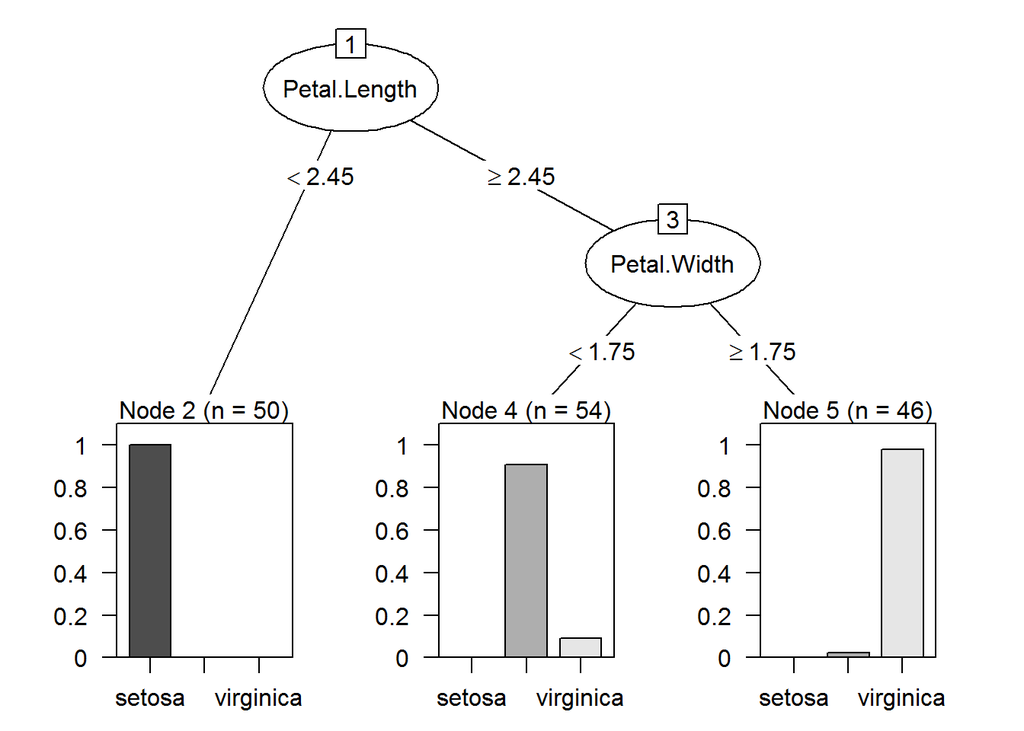

```r
library(partykit)
plot(as.party(myFirstTree))
```

### 1.6.1 Quality of Classification

For example, in a two-class problem with 400 observations in each class (denote this by (400, 400)), suppose one split created nodes (300, 100) and (100, 300), while the other created nodes (200, 400) and (200, 0). Compute the misclassification rate and write it down formally.

## 1.7 Gini Index

### 1.7.1 Node Impurity in trees

A classification tree is built by the following process: first the single variable is found which best splits the data into two groups (`best’ will be defined shortly). The data is separated, and then this process is applied *separately* to each sub-group, and so on recursively until the subgroups either reach a minimum size or until no improvement can be made.

The partitioning method can be applied to many different kinds of data. We will start by looking at the classification problem, which is one of the more instructive cases (but also has the most complex equations). The sample population consists of $n$ observations from $K$ classes. A given model will break these observations into $k$ terminal groups; to each of these groups is assigned a predicted class.

Most tree algorithms use one of several measures of impurity, or diversity, of a node. Let us denote $\hat{p}_{mk}$ as the proportion of training observations in the $m$th region that are from the $k$th class. We then define the *Gini index* as
$$G_m = \sum_{i=1}^K { \hat{p}_{mk}(1 - \hat{p}_{mk} ) }$$
Remembering $p (1-p)$ to be the variance of the Bernoulli distribution, the Gini index measures the total variance across the $K$ classes. For nearly “pure” regions (all $\hat{p}_{mk}$ being close to 0 or 1), it takes on a very small value.

An alternative measure is given by the information index or *cross entropy*
$$D_m = - \sum_{i=1}^K { \hat{p}_{mk} \log{ \hat{p}_{mk} } }$$

NOTE: The expressions above are general enough for multiple category classification and hence more complicated than the version discussed in class.For binary outcomes $(y \in 0,1)$ the Gini index reduces to simply
$$G_m = 2 \hat{p}_m (1 - \hat{p}_m )$$

The two impurity functions are plotted in the figure below, along with a rescaled version of the Gini measure. For the two class problem the measures differ only slightly, and will nearly always choose the same split point.

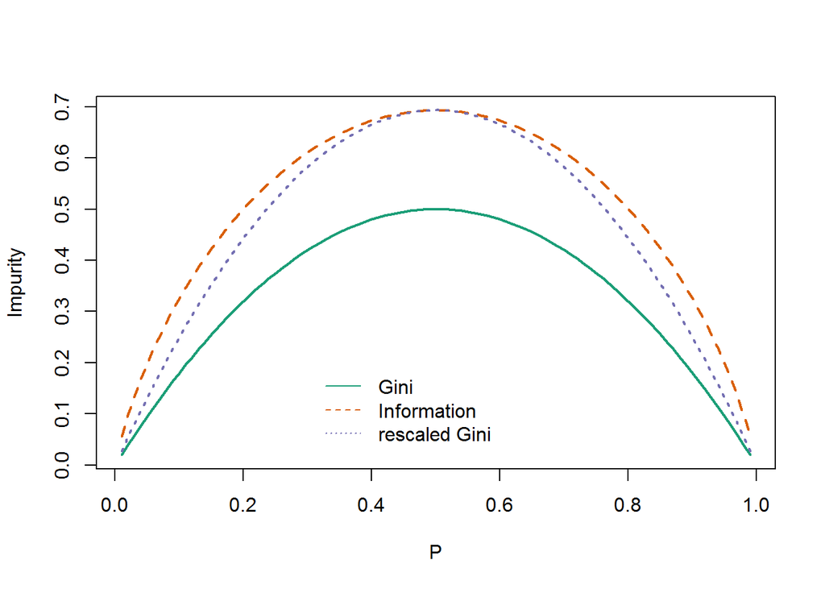

For the total split impurity, we need to weight the node impurity measures by the number $N_{mL}$ and $N_{mR}$ of observations in the two child nodes (“left” L and “right” R) created by splitting node $m$.

### 1.7.2 Titanic data

BUilding a tree on the Titanic survival data:

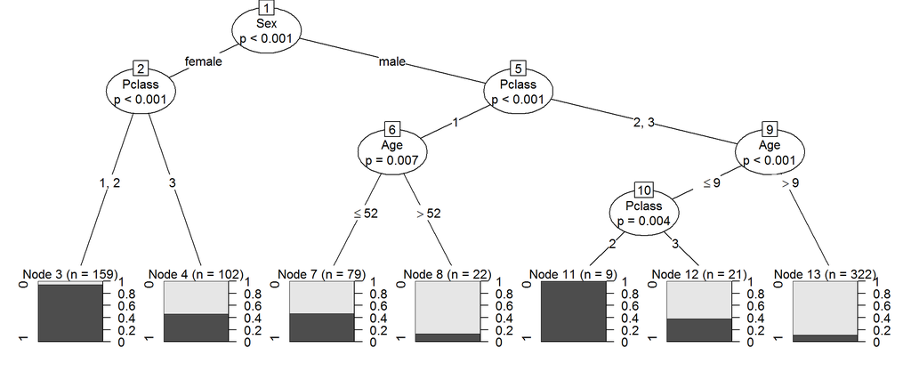

```r
#train <- read.csv("../data/TitanicTrain.csv")
library(partykit, quietly = TRUE)
train$Pclass = factor(train$Pclass)
train$Survived = factor(train$Survived)

naRows = is.na(train$Age)

fit = ctree(Survived ~ Age + Sex + Pclass, data= train[!naRows,])
plot(fit)
```

Why does the tree **not** split on passenger class 1 and 2 for female passengers ?

```r
FemalePclass12 = subset(train[!naRows,], Sex =="female" & Pclass %in% 1:2)
(ST=table(FemalePclass12$Survived, FemalePclass12$Pclass))
```

```
##
##      1  2  3
##   0  3  6  0
##   1 82 68  0
```

```r
x=ST["1",1:2]
n=colSums(ST[,1:2])

prop.test(x,n)
```

```
##
##  2-sample test for equality of proportions with continuity
##  correction
##
## data:  x out of n
## X-squared = 0.814, df = 1, p-value = 0.3669
## alternative hypothesis: two.sided
## 95 percent confidence interval:
##  -0.04038138  0.13195530
## sample estimates:
##    prop 1    prop 2
## 0.9647059 0.9189189
```

Why does the tree **not** split on male passengers older than 9 years and classes 2 and 3

```r
MalePclass23 = subset(train[!naRows,], Sex =="male" & Pclass %in% 2:3 & Age > 9)
(ST=table(MalePclass23$Survived, MalePclass23$Pclass))
```

```
##
##       1   2   3
##   0   0  84 202
##   1   0   6  30
```

```r
x=ST["1",2:3]
n=colSums(ST[,2:3])

prop.test(x,n)
```

```
##
##  2-sample test for equality of proportions with continuity
##  correction
##
## data:  x out of n
## X-squared = 1.9705, df = 1, p-value = 0.1604
## alternative hypothesis: two.sided
## 95 percent confidence interval:
##  -0.13758592  0.01229856
## sample estimates:
##     prop 1     prop 2
## 0.06666667 0.12931034
```

Somewhat hard to believe that we find a statistically significant difference in survival probability among 1st class males that are above and below age 52 !?:

```r
MalePclass1 = subset(train[!naRows,], Sex =="male" & Pclass %in% 1 )
(ST=table(MalePclass1$Survived, MalePclass1$Age > 52))
```

```
##
##     FALSE TRUE
##   0    42   19
##   1    37    3
```

```r
x=ST["1",]
n=colSums(ST)

prop.test(x,n)
```

```
##
##  2-sample test for equality of proportions with continuity
##  correction
##
## data:  x out of n
## X-squared = 6.602, df = 1, p-value = 0.01019
## alternative hypothesis: two.sided
## 95 percent confidence interval:
##  0.1221815 0.5418001
## sample estimates:
##    prop 1    prop 2
## 0.4683544 0.1363636
```

```r
k=2
p=0.01019
1 - (1 - p)^k
```

```
## [1] 0.02027616
```

### 1.7.3 Surrogate Splits

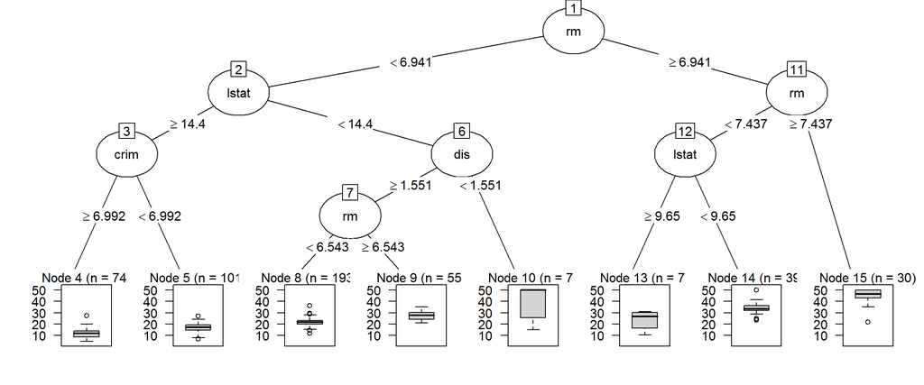

```r
library(rpart)
library(partykit, quietly = TRUE)

library(MASS)
fitWithSurrogates=rpart(medv~.,Boston)
plot(as.party(fitWithSurrogates))
```

```r
summary(fitWithSurrogates)
```

```
## Call:
## rpart(formula = medv ~ ., data = Boston)
##   n= 506
##
##           CP nsplit rel error    xerror       xstd
## 1 0.45274420      0 1.0000000 1.0045614 0.08315279
## 2 0.17117244      1 0.5472558 0.6373816 0.05945744
## 3 0.07165784      2 0.3760834 0.4065187 0.04512711
## 4 0.03616428      3 0.3044255 0.3594928 0.04240295
## 5 0.03336923      4 0.2682612 0.3372991 0.04285681
## 6 0.02661300      5 0.2348920 0.3279057 0.04079749
## 7 0.01585116      6 0.2082790 0.2976916 0.04029509
## 8 0.01000000      7 0.1924279 0.2698034 0.03745537
##
## Variable importance
##      rm   lstat     dis   indus     tax ptratio     nox     age    crim
##      33      21       7       7       6       6       6       6       4
##      zn     rad   black
##       2       1       1
##
## Node number 1: 506 observations,    complexity param=0.4527442
##   mean=22.53281, MSE=84.41956
##   left son=2 (430 obs) right son=3 (76 obs)
##   Primary splits:
##       rm      < 6.941    to the left,  improve=0.4527442, (0 missing)
##       lstat   < 9.725    to the right, improve=0.4423650, (0 missing)
##       indus   < 6.66     to the right, improve=0.2594613, (0 missing)
##       ptratio < 19.9     to the right, improve=0.2443727, (0 missing)
##       nox     < 0.6695   to the right, improve=0.2232456, (0 missing)
##   Surrogate splits:
##       lstat   < 4.83     to the right, agree=0.891, adj=0.276, (0 split)
##       ptratio < 14.55    to the right, agree=0.875, adj=0.171, (0 split)
##       zn      < 87.5     to the left,  agree=0.862, adj=0.079, (0 split)
##       indus   < 1.605    to the right, agree=0.862, adj=0.079, (0 split)
##       crim    < 0.013355 to the right, agree=0.852, adj=0.013, (0 split)
##
## Node number 2: 430 observations,    complexity param=0.1711724
##   mean=19.93372, MSE=40.27284
##   left son=4 (175 obs) right son=5 (255 obs)
##   Primary splits:
```

[output cut: 95 more lines]

```
##
## Node number 11: 7 observations
##   mean=38, MSE=204.1457
##
## Node number 12: 7 observations
##   mean=23.05714, MSE=61.85673
##
## Node number 13: 39 observations
##   mean=33.73846, MSE=20.24391
##
## Node number 20: 193 observations
##   mean=21.65648, MSE=8.23738
##
## Node number 21: 55 observations
##   mean=27.42727, MSE=11.69398
```

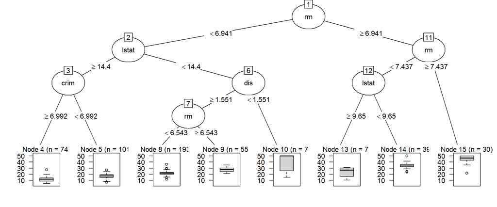

```r
fitNoSurrogates=rpart(medv~.,Boston, maxsurrogate = 0)
plot(as.party(fitNoSurrogates))
```

```r
summary(fitNoSurrogates)
```

```
## Call:
## rpart(formula = medv ~ ., data = Boston, maxsurrogate = 0)
##   n= 506
##
##           CP nsplit rel error    xerror       xstd
## 1 0.45274420      0 1.0000000 1.0043166 0.08289617
## 2 0.17117244      1 0.5472558 0.6685812 0.06072353
## 3 0.07165784      2 0.3760834 0.4451655 0.04959333
## 4 0.03616428      3 0.3044255 0.3594221 0.04446244
## 5 0.03336923      4 0.2682612 0.3497856 0.04499382
## 6 0.02661300      5 0.2348920 0.3251981 0.04393227
## 7 0.01585116      6 0.2082790 0.2804374 0.03921801
## 8 0.01000000      7 0.1924279 0.2615230 0.03434855
##
## Variable importance
##    rm lstat   dis  crim
##    69    23     4     3
##
## Node number 1: 506 observations,    complexity param=0.4527442
##   mean=22.53281, MSE=84.41956
##   left son=2 (430 obs) right son=3 (76 obs)
##   Primary splits:
##       rm      < 6.941    to the left,  improve=0.4527442, (0 missing)
##       lstat   < 9.725    to the right, improve=0.4423650, (0 missing)
##       indus   < 6.66     to the right, improve=0.2594613, (0 missing)
##       ptratio < 19.9     to the right, improve=0.2443727, (0 missing)
##       nox     < 0.6695   to the right, improve=0.2232456, (0 missing)
##
## Node number 2: 430 observations,    complexity param=0.1711724
##   mean=19.93372, MSE=40.27284
##   left son=4 (175 obs) right son=5 (255 obs)
##   Primary splits:
##       lstat   < 14.4     to the right, improve=0.4222277, (0 missing)
##       nox     < 0.6695   to the right, improve=0.2775455, (0 missing)
##       crim    < 5.84803  to the right, improve=0.2483622, (0 missing)
##       ptratio < 19.9     to the right, improve=0.2199328, (0 missing)
##       age     < 75.75    to the right, improve=0.2089435, (0 missing)
##
## Node number 3: 76 observations,    complexity param=0.07165784
##   mean=37.23816, MSE=79.7292
```

[output cut: 56 more lines]

```
##
## Node number 11: 7 observations
##   mean=38, MSE=204.1457
##
## Node number 12: 7 observations
##   mean=23.05714, MSE=61.85673
##
## Node number 13: 39 observations
##   mean=33.73846, MSE=20.24391
##
## Node number 20: 193 observations
##   mean=21.65648, MSE=8.23738
##
## Node number 21: 55 observations
##   mean=27.42727, MSE=11.69398
```

Let us predict on two new data points where we introduce missing values:

```r
head(Boston[,c("rm", "lstat", "crim", "dis")],2)
```

```
##      rm lstat    crim    dis
## 1 6.575  4.98 0.00632 4.0900
## 2 6.421  9.14 0.02731 4.9671
```

```r
newX=head(Boston,2)
predict(fitWithSurrogates, newdata=newX)
```

```
##        1        2
## 27.42727 21.65648
```

```r
#nodes 9 and 8
newX$rm=mean(c(NA))
predict(fitWithSurrogates, newdata=newX)
```

```
##        1        2
## 27.42727 21.65648
```

[figure not shown]

```r
# Primary splits:
#      rm      < 6.941    to the left,  improve=0.4527442, (0 missing)
#Surrogate splits:
#      lstat   < 4.83     to the right, agree=0.891, adj=0.276, (0 split)
Boston$PrimarySplit = Boston$rm < 6.941
Boston$SurrogateSplit = Boston$lstat   > 4.83
boxplot(medv ~ PrimarySplit, at = (1:2)*2.5, col = "blue", data = Boston, xlim = c(2, 7), ylim = range(0,50),xaxt = "n", ylab = "medv")
boxplot(medv ~ SurrogateSplit, at = (1:2)*2.5+1, col = "bisque", data = Boston, xaxt = "n", add = TRUE)
grid();title("Primary vs. surrogate split")
axis(1, at = c((1:2)*2.5,(1:2)*2.5+1), labels = c("rm < 6.94","rm > 6.94", "lstat > 4.83", "lstat < 4.83"), tick = TRUE)
```

```r
#or ggplot:
#library(ggplot2)
#q <- qplot(PrimarySplit,medv,data=Boston,geom="boxplot")
#q + theme(axis.text.x = element_text(angle = 45, hjust = 1))

#library(lattice)
#bwplot(medv ~ PrimarySplit | SurrogateSplit, data = Boston)
```

### 1.7.4 Comparing ROC curves

```r
myROC = function(fits,
                 TrueCategory=train$Survived,
                 train
){
  ROC = list()
  lab = names(fits)
  M=length(fits)

  for (k in 1:M ){
    cat("working on", lab[k], "\n")
    if (lab[k]=="rpart" | lab[k]== "party")
       preds = predict(fits[[k]], newdata=train, type="prob")[,2]
    else
      preds = predict(fits[[k]], newdata=train, type="response")
    FPR=FNR=TPR=vector()
    pCutoffs = seq(0.025,0.975, by = 0.01)

    for (i in 1:length(pCutoffs)){
      SurvPreds = factor(preds > pCutoffs[i], levels = c(TRUE,FALSE))
      ConfMat = table(SurvPreds, TrueCategory)
      TN = sum(ConfMat[,1])#true negatives
      TP = sum(ConfMat[,2])#true positives

      FPR[i] = ConfMat[2,1]/TN # False Positive Rate
      FNR[i] = ConfMat[1,2]/TP # False Negative Rate
      #TPR proportion of positives that are correctly identified
      TPR[i] = ConfMat[2,2]/TP
    }
    ROC[[k]] = cbind(FPR,TPR)
  }

  plot(FPR ~ TPR, data = ROC[[1]], type="l", lwd=2, main = "ROC curve", xlim=c(0,1), ylim=c(0,1));grid()
  if (M>1)
    for (k in 2:M)
     lines(FPR ~ TPR, data = ROC[[k]], col=k,lwd=2)

  legend("bottomright", col=1:M,lwd=2,legend=lab)
}
```

```r
fit1 = glm(Survived ~ Sex + Age + Pclass, family = binomial, data = na.omit(train))

fit2 = rpart(Survived ~ Sex + Age + Pclass, data = train)

fit3 = ctree(Survived ~ Age + Sex + Pclass, data= train)

fits=list(fit1, fit2, fit3);names(fits)=c("glm", "rpart", "party")
myROC(fits,train=train)
```

```
## working on glm
## working on rpart
## working on party
```

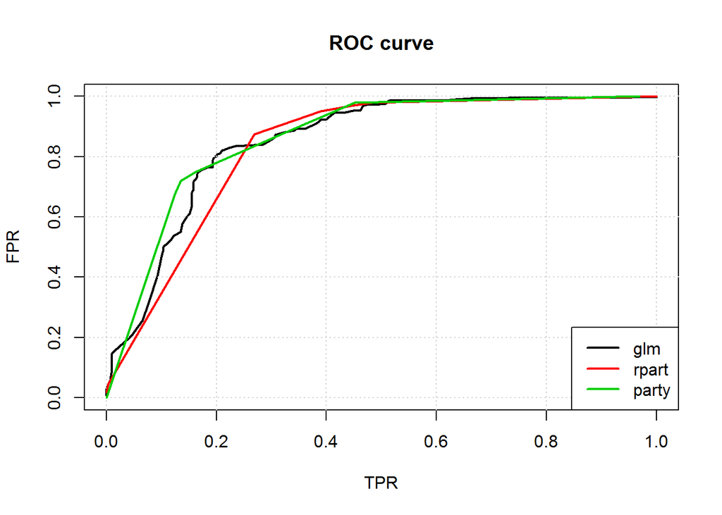

### 1.7.5 Regression Trees

```r
library(tree)

library(MASS)
set.seed(1)
train = sample(1:nrow(Boston), nrow(Boston)/2)
tree.boston=tree(medv~.,Boston,subset=train,minsize = 8, mindev = 0.005)
summary(tree.boston)
```

```
##
## Regression tree:
## tree(formula = medv ~ ., data = Boston, subset = train, minsize = 8,
##     mindev = 0.005)
## Variables actually used in tree construction:
## [1] "lstat" "rm"    "age"   "nox"   "tax"
## Number of terminal nodes:  12
## Residual mean deviance:  10.64 = 2564 / 241
## Distribution of residuals:
##     Min.  1st Qu.   Median     Mean  3rd Qu.     Max.
## -15.6500  -1.9380  -0.0375   0.0000   1.7600  13.0900
```

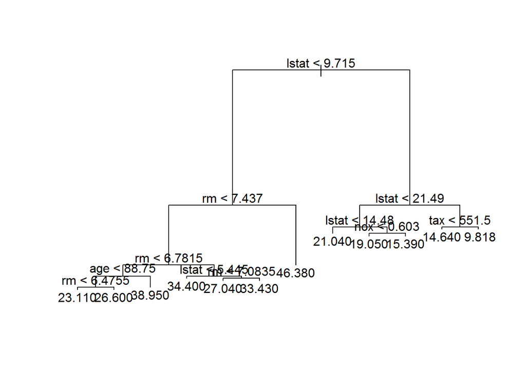

```r
plot(tree.boston)#, margin = 0.05)
text(tree.boston,pretty=0)
```

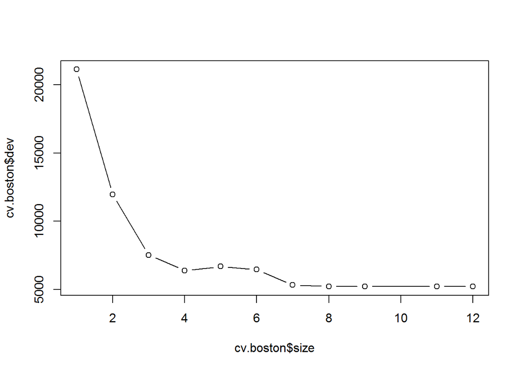

```r
cv.boston=cv.tree(tree.boston)
plot(cv.boston$size,cv.boston$dev,type='b')
```

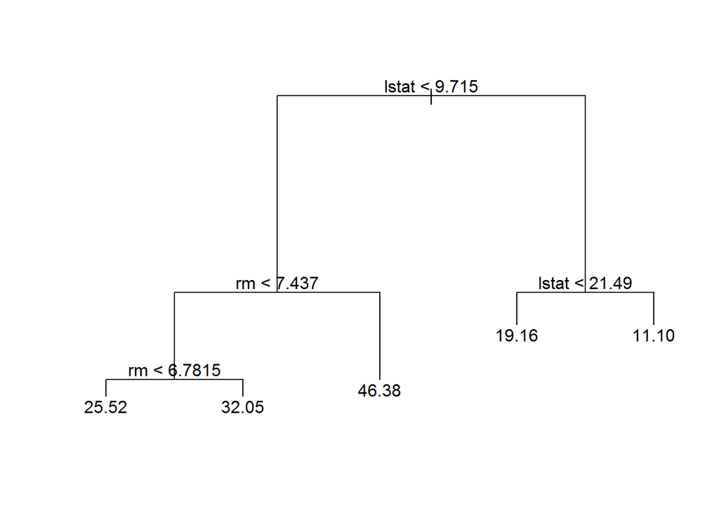

```r
prune.boston=prune.tree(tree.boston,best=5)
plot(prune.boston)
text(prune.boston,pretty=0)
```

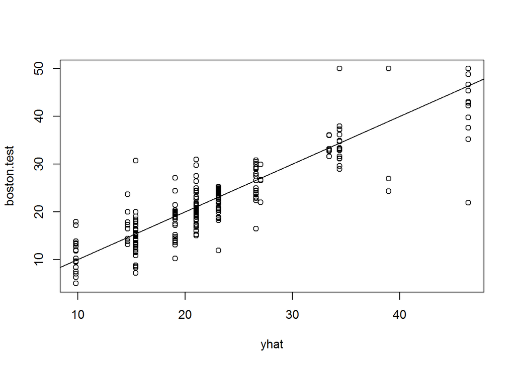

```r
yhat=predict(tree.boston,newdata=Boston[-train,])
boston.test=Boston[-train,"medv"]
plot(yhat,boston.test)
abline(0,1)
```

```r
mean((yhat-boston.test)^2)
```

```
## [1] 17.86726
```

## 1.8 Variable Selection

### 1.8.1 Bigger is better ? More variables = better ?

#### 1.8.1.1 churn

```r
churn <- read.csv("data/churn.csv", stringsAs=TRUE)
set.seed(1)
train=sample( nrow(churn), 400)

#fitSmall = glm(Churn ~ CellPlan + Sex + Age, data = churn[train,], family = binomial)
fitSmall = glm(Churn ~ CellPlan + Sex + Age, data = churn[train,-14], family = binomial)
predSmall = predict(fitSmall, newdata = churn[-train,], type="response")
(ConfMatSmall = table(predSmall>0.5,churn[-train,"Churn"]))
```

```
##
##           0   1
##   FALSE 156  31
##   TRUE   31  96
```

```r
(Accuracy = round(sum(diag(ConfMatSmall))/sum(ConfMatSmall) , 2))
```

```
## [1] 0.8
```

```r
#model matrix

mm = model.matrix(Churn ~ CellPlan + Sex + Age - 1, data = churn[train,])
mm = model.matrix(fitSmall)

# wide data (p > n)

#IllConsidered = glm(Churn ~ ., data = churn[1:20,], family = binomial)
```

#### 1.8.1.2 Your turn: repeat for BIG model !

### 1.8.2 Best Subset Selection

#### 1.8.2.1 Quiz: how many models need to be fitted for $p$ predictors ?

```r
library(leaps)
#regfit.full=regsubsets(Salary~.,Hitters)
#summary(regfit.full)
regfit.full=regsubsets(Salary ~.,data=Hitters,nvmax=19)
reg.summary=summary(regfit.full)

reg.summary$rsq
```

```
##  [1] 0.3214501 0.4252237 0.4514294 0.4754067 0.4908036 0.5087146 0.5141227
##  [8] 0.5285569 0.5346124 0.5404950 0.5426153 0.5436302 0.5444570 0.5452164
## [15] 0.5454692 0.5457656 0.5459518 0.5460945 0.5461159
```

```r
par(mfrow=c(2,2))
plot(reg.summary$rss,xlab="Number of Variables",ylab="RSS",type="l")
plot(reg.summary$adjr2,xlab="Number of Variables",ylab="Adjusted RSq",type="l")
#which.max(reg.summary$adjr2)
points(11,reg.summary$adjr2[11], col="red",cex=2,pch=20)
plot(reg.summary$cp,xlab="Number of Variables",ylab="Cp",type='l')
#which.min(reg.summary$cp)
points(10,reg.summary$cp[10],col="red",cex=2,pch=20)
which.min(reg.summary$bic)
```

```
## [1] 6
```

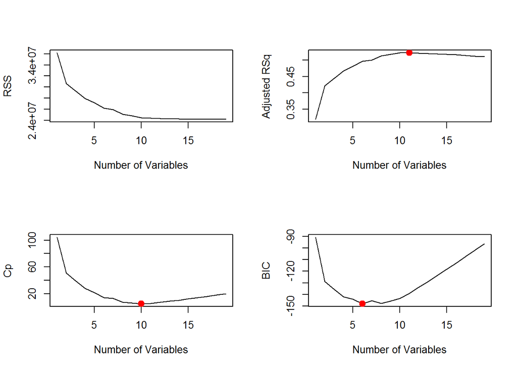

```r
plot(reg.summary$bic,xlab="Number of Variables",ylab="BIC",type='l')
points(6,reg.summary$bic[6],col="red",cex=2,pch=20)
```

```r
coef(regfit.full,6)
```

```
##  (Intercept)        AtBat         Hits        Walks         CRBI
##   91.5117981   -1.8685892    7.6043976    3.6976468    0.6430169
##    DivisionW      PutOuts
## -122.9515338    0.2643076
```

### 1.8.3 Forward and Backward Stepwise Selection

Unlike best subset selection, which involved fitting $2^p$ models, forward stepwise selection involves fitting one null model, along with $p-k$ models in the $k$th iteration, for $k = 0, \ldots , p -1$. This amounts to a total of
$$1 + \sum_{k=0}^{p-1}{(p-k)} = 1+p(p+1)/2$$
models. This is a substantial difference: when $p = 20$, best subset selection requires fitting $1,048,576$ models, whereas forward stepwise selection requires fitting only $211$ models.

```r
regfit.fwd=regsubsets(Salary~.,data=Hitters,nvmax=19,method="forward")
#summary(regfit.fwd)
regfit.bwd=regsubsets(Salary~.,data=Hitters,nvmax=19,method="backward")
#summary(regfit.bwd)
coef(regfit.full,7)
```

```
##  (Intercept)         Hits        Walks       CAtBat        CHits
##   79.4509472    1.2833513    3.2274264   -0.3752350    1.4957073
##       CHmRun    DivisionW      PutOuts
##    1.4420538 -129.9866432    0.2366813
```

```r
coef(regfit.fwd,7)
```

```
##  (Intercept)        AtBat         Hits        Walks         CRBI
##  109.7873062   -1.9588851    7.4498772    4.9131401    0.8537622
##       CWalks    DivisionW      PutOuts
##   -0.3053070 -127.1223928    0.2533404
```

```r
coef(regfit.bwd,7)
```

```
##  (Intercept)        AtBat         Hits        Walks        CRuns
##  105.6487488   -1.9762838    6.7574914    6.0558691    1.1293095
##       CWalks    DivisionW      PutOuts
##   -0.7163346 -116.1692169    0.3028847
```

```r
regfit.sqr=regsubsets(Salary~.,data=Hitters,nvmax=19,method="seqrep")
```

- There is one more option *seqrep* for sequential replacement (an approach which considers both forward and backward steps)
- The package leaps is VERY fast because it uses an “efficient branch-and-bound algorithm”.

### 1.8.4 Visualization

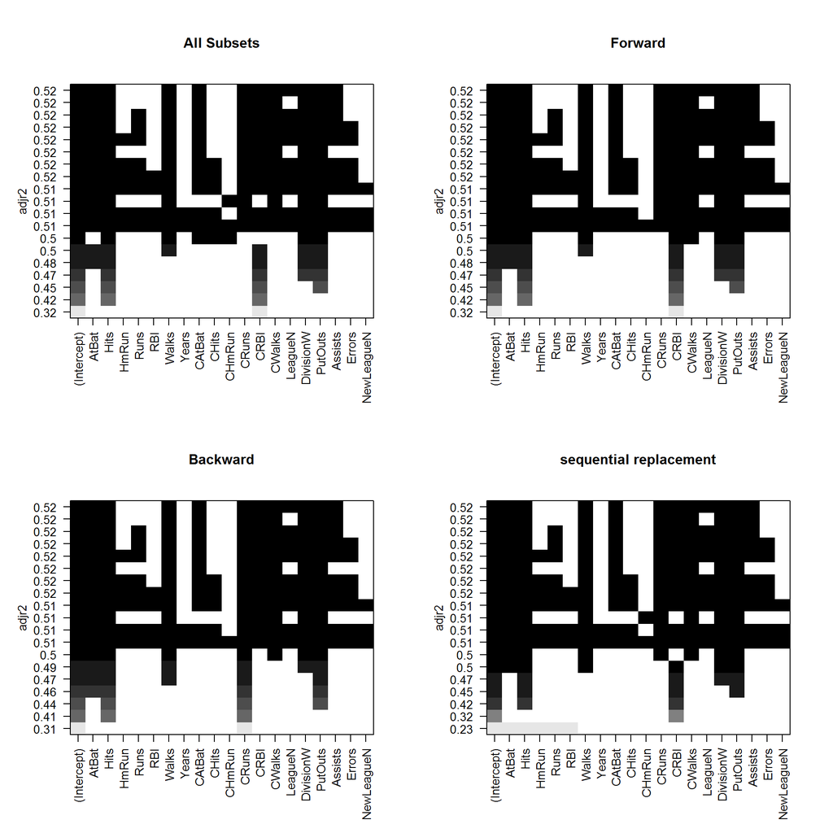

```r
par(mfrow=c(2,2))
plot(regfit.full, scale = "adjr2", main = "All Subsets")
plot(regfit.fwd, scale = "adjr2", main = "Forward")
plot(regfit.bwd, scale = "adjr2", main = "Backward")
plot(regfit.sqr, scale = "adjr2", main = "sequential replacement")
```

# 2 Choosing Among Models

```r
set.seed(1)
train=sample(c(TRUE,FALSE), nrow(Hitters),rep=TRUE)
test=(!train)
regfit.best=regsubsets(Salary~.,data=Hitters[train,],nvmax=19)
test.mat=model.matrix(Salary~.,data=Hitters[test,])
val.errors=rep(NA,19)
for(i in 1:19){
   coefi=coef(regfit.best,id=i)
   pred=test.mat[,names(coefi)]%*%coefi
   val.errors[i]=mean((Hitters$Salary[test]-pred)^2)
}
val.errors
```

```
##  [1] 220968.0 169157.1 178518.2 163426.1 168418.1 171270.6 162377.1
##  [8] 157909.3 154055.7 148162.1 151156.4 151742.5 152214.5 157358.7
## [15] 158541.4 158743.3 159972.7 159859.8 160105.6
```

```r
which.min(val.errors)
```

```
## [1] 10
```

```r
coef(regfit.best,10)
```

```
## (Intercept)       AtBat        Hits       Walks      CAtBat       CHits
## -80.2751499  -1.4683816   7.1625314   3.6430345  -0.1855698   1.1053238
##      CHmRun      CWalks     LeagueN   DivisionW     PutOuts
##   1.3844863  -0.7483170  84.5576103 -53.0289658   0.2381662
```

## 2.1 Greedy Algorithms

- In the computer science literature, stepwise approaches are known as **greedy algorithms**, in the sense that they operate according to grabbing the variable that will help most in the short term
- However, just as this is not always the best strategy in other areas of life, there is no guarantee that the stepwise approach will find the best model

## 2.2 Task before moving on: Using a selection method of your choice find the best housing model and submit to kaggle !

```r
train <- read.csv("data/HousePrices/train.csv.gz")
test <- read.csv("data/HousePrices/test.csv.gz")
test$SalePrice = NA

setdiff(colnames(train), colnames(test))
```

```
## character(0)
```

```r
train = train[,intersect(colnames(train), colnames(test))]


jj = is.na(train$SalePrice)
train$SalePrice[jj] = mean(train$SalePrice, na.rm=TRUE)
#remove NAs
mv = colSums(sapply(train, is.na))
train = train[,mv==0]

# What is the size of the model.matrix ?
tmp = model.matrix(SalePrice ~. , data=train)
# remove factors
xC = sapply(train, class)
train = train[,xC != "factor"]

forward=regsubsets(log(SalePrice) ~.,data=train,nvmax=35,method="forward")
```

```
## Reordering variables and trying again:
```

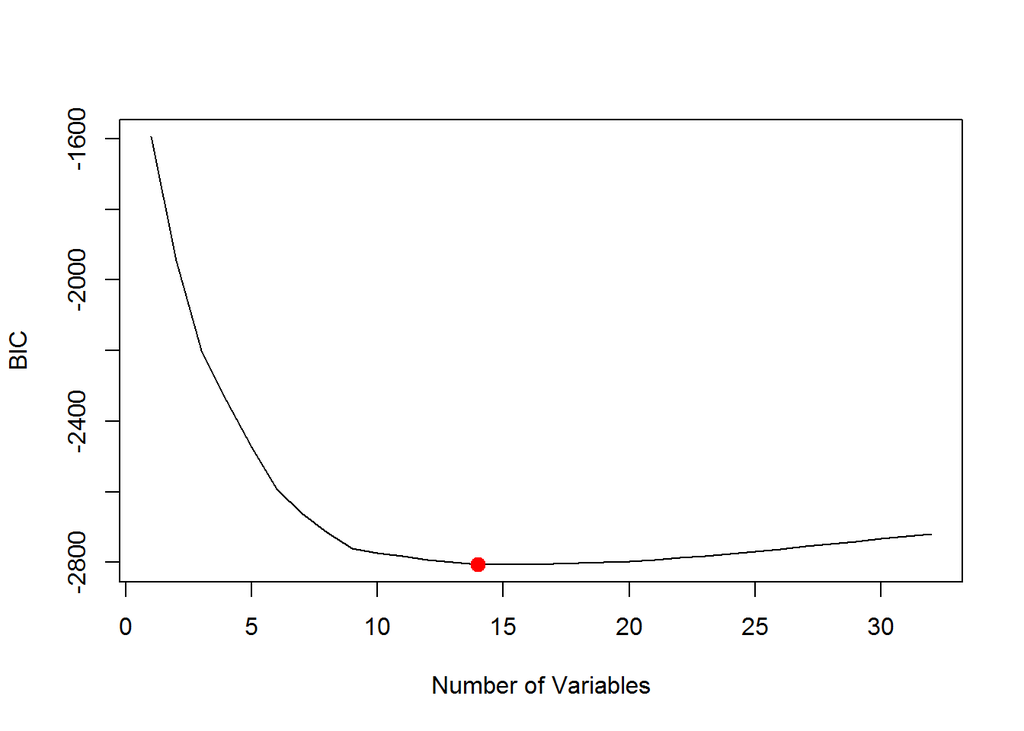

```r
fs = summary(forward)

plot(fs$bic,xlab="Number of Variables",ylab="BIC",type='l')
k=which.min(fs$bic)
points(k,fs$bic[k],col="red",cex=2,pch=20)
```

```r
coefi=coef(forward,id=k)
names(coefi)
```

```
##  [1] "(Intercept)"   "MSSubClass"    "LotArea"       "OverallQual"
##  [5] "OverallCond"   "YearBuilt"     "YearRemodAdd"  "X1stFlrSF"
##  [9] "BsmtHalfBath"  "FullBath"      "GarageArea"    "WoodDeckSF"
## [13] "EnclosedPorch" "MiscVal"       "MoSold"
```

```r
mm = model.matrix(SalePrice ~. , data=train)
logpredsTrain =mm[,names(coefi)] %*% coefi

names(coefi)[-1] %in% colnames(test)
```

```
##  [1] TRUE TRUE TRUE TRUE TRUE TRUE TRUE TRUE TRUE TRUE TRUE TRUE TRUE TRUE
```

```r
Id= test$Id
test=test[,names(coefi)[-1]]


MeanImpute = function(x){
  for (i in which(colSums(is.na(test))>0)) {
    jj = which(is.na(test[,i]))
    test[jj,i] = mean(test[,i],na.rm=TRUE)
  }
  return(test)
}

test = MeanImpute(test)

mmTest = model.matrix( ~ . , data=test)
logpredTest = mmTest %*% coefi


subMiss = cbind.data.frame(Id= Id,SalePrice= exp(logpredTest))
#write.csv(subMiss, "data/HousePrices/submission2.csv", quote=F, row.names = FALSE
```

# 3 Regularization:

Let us start with two quotes from **Kaggle chief scientist Jeremy Howard**:

#### 3.0.0.1 1. “lasso and elastic-net regularized generalized linear models are fast, work on huge data sets, and avoid over-fitting automatically. They are available in the glmnet package in R.”

#### 3.0.0.2 2. “For black box prediction ensembles of decision trees have been the most successful general-purpose algorithm in modern times. For instance, most Kaggle competitions have at least one top entry that heavily uses this approach. This algorithm is very simple to understand, and is fast and easy to apply. It is available in the randomForest package in R.”

## 3.1 Ridge Regression

Recall our new penalty term in finding the coefficients $\beta_j$ the minimization

$$\sum_{i=1}^n{\left( y_i - \beta_0 - \sum_{j=1}^p{\beta_j x_{ij}} \right)^2} + \lambda \sum_{j=1}^p{\beta_j^2} = RSS + \lambda \sum_{j=1}^p{\beta_j^2}$$

Instead of obtaining **one** set of coefficients we have a dependency of $\beta_j$ on $\lambda$:

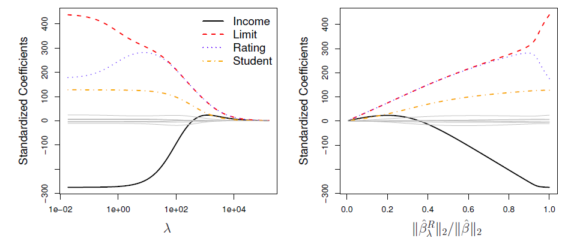

```r
library(ISLR)
data(Hitters)
Hitters = na.omit(Hitters)

x=model.matrix(Salary~.,Hitters)[,-1]
y=Hitters$Salary
set.seed(1)
train=sample(1:nrow(x), nrow(x)/2)
test=(-train)
y.test=y[test]


fit=lm(Salary~.,Hitters[train,])
sqrt(mean((predict(fit,new=Hitters[-train,])-y.test)^2))
```

```
## [1] 338.7929
```

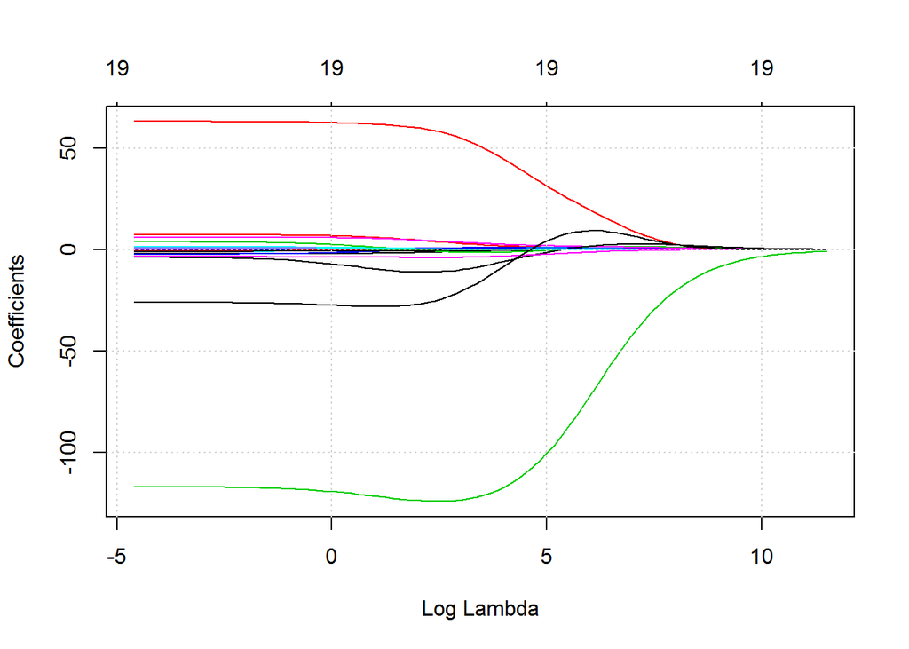

```r
library(glmnet)
 grid=10^seq(5,-2,length=100)
 ridge.mod=glmnet(x,y,alpha=0,lambda=grid)

 plot(ridge.mod, xvar = "lambda");grid()
```

How do we know which variable is which ? Recall that $\lambda$ is decreasing with column index:

```r
dim(coef(ridge.mod))
```

```
## [1]  20 100
```

```r
#View(as.matrix(coef(ridge.mod)))
head(round(sort(coef(ridge.mod)[,100]),2))
```

```
##  DivisionW NewLeagueN      Years     Errors       Runs      AtBat
##    -117.09     -25.94      -3.73      -3.42      -2.21      -1.97
```

```r
tail(round(sort(coef(ridge.mod)[,100]),2))
```

```
##       CRuns       HmRun       Walks        Hits     LeagueN (Intercept)
##        1.37        3.95        6.20        7.38       63.36      164.12
```

In general, finding the optimum $\lambda$ is best done using cross-validation. We can do this using the built-in cross-validation function, cv.glmnet(). By default, the function *cv.glmnet()* performs ten-fold cross-validation, though this can be changed using the argument *nfolds*.

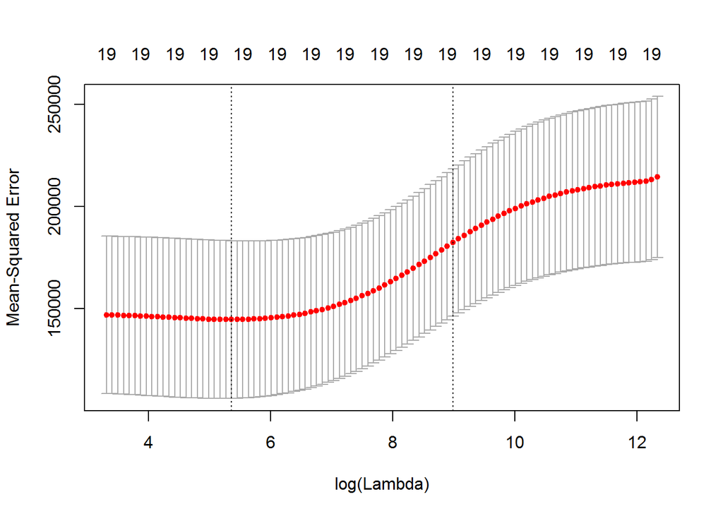

```r
set.seed(1)
cv.out=cv.glmnet(x[train,],y[train],alpha=0)
plot(cv.out)
```

```r
bestlam=cv.out$lambda.min
bestlam
```

```
## [1] 211.7416
```

```r
ridge.pred=predict(ridge.mod,s=bestlam,newx=x[test,])
mean((ridge.pred-y.test)^2)
```

```
## [1] 80297.49
```

```r
out=glmnet(x,y,alpha=0)
predict(out,type="coefficients",s=bestlam)[1:20,]
```

```
##  (Intercept)        AtBat         Hits        HmRun         Runs
##   9.88487157   0.03143991   1.00882875   0.13927624   1.11320781
##          RBI        Walks        Years       CAtBat        CHits
##   0.87318990   1.80410229   0.13074383   0.01113978   0.06489843
##       CHmRun        CRuns         CRBI       CWalks      LeagueN
##   0.45158546   0.12900049   0.13737712   0.02908572  27.18227527
##    DivisionW      PutOuts      Assists       Errors   NewLeagueN
## -91.63411282   0.19149252   0.04254536  -1.81244470   7.21208394
```

None of the coefficients are zero; ridge regression does not perform variable selection!